### Classification, Performance Estimation and Regularization by Sofia Nomikou

In this lab we are going to explore Classification techiques and apply them on biomedical data. We will study Logistic Regression and K-Nearest Neighbors. Let’s begin!

### Classification

For our lab today we are going to use the Wisconsin Breast Cancer data set.

```r
library(mlbench)
data(BreastCancer)
str(BreastCancer)
```

```
## 'data.frame':    699 obs. of  11 variables:
##  $ Id             : chr  "1000025" "1002945" "1015425" "1016277" ...
##  $ Cl.thickness   : Ord.factor w/ 10 levels "1"<"2"<"3"<"4"<..: 5 5 3 6 4 8 1 2 2 4 ...
##  $ Cell.size      : Ord.factor w/ 10 levels "1"<"2"<"3"<"4"<..: 1 4 1 8 1 10 1 1 1 2 ...
##  $ Cell.shape     : Ord.factor w/ 10 levels "1"<"2"<"3"<"4"<..: 1 4 1 8 1 10 1 2 1 1 ...
##  $ Marg.adhesion  : Ord.factor w/ 10 levels "1"<"2"<"3"<"4"<..: 1 5 1 1 3 8 1 1 1 1 ...
##  $ Epith.c.size   : Ord.factor w/ 10 levels "1"<"2"<"3"<"4"<..: 2 7 2 3 2 7 2 2 2 2 ...
##  $ Bare.nuclei    : Factor w/ 10 levels "1","2","3","4",..: 1 10 2 4 1 10 10 1 1 1 ...
##  $ Bl.cromatin    : Factor w/ 10 levels "1","2","3","4",..: 3 3 3 3 3 9 3 3 1 2 ...
##  $ Normal.nucleoli: Factor w/ 10 levels "1","2","3","4",..: 1 2 1 7 1 7 1 1 1 1 ...
##  $ Mitoses        : Factor w/ 9 levels "1","2","3","4",..: 1 1 1 1 1 1 1 1 5 1 ...
##  $ Class          : Factor w/ 2 levels "benign","malignant": 1 1 1 1 1 2 1 1 1 1 ...
```

```r
BreastCancer$Cl.thickness <- as.numeric(as.character(BreastCancer$Cl.thickness))
BreastCancer$Cell.size <- as.numeric(as.character(BreastCancer$Cell.size))
BreastCancer$Cell.shape <- as.numeric(as.character(BreastCancer$Cell.shape))
BreastCancer$Marg.adhesion <- as.numeric(as.character(BreastCancer$Marg.adhesion))
BreastCancer$Epith.c.size <- as.numeric(as.character(BreastCancer$Epith.c.size))
BreastCancer$Bare.nuclei <- as.numeric(as.character(BreastCancer$Bare.nuclei))
BreastCancer$Bl.cromatin <- as.numeric(as.character(BreastCancer$Bl.cromatin))
BreastCancer$Normal.nucleoli <- as.numeric(as.character(BreastCancer$Normal.nucleoli))
BreastCancer$Mitoses <- as.numeric(as.character(BreastCancer$Mitoses))

str(BreastCancer)
```

```
## 'data.frame':    699 obs. of  11 variables:
##  $ Id             : chr  "1000025" "1002945" "1015425" "1016277" ...
##  $ Cl.thickness   : num  5 5 3 6 4 8 1 2 2 4 ...
##  $ Cell.size      : num  1 4 1 8 1 10 1 1 1 2 ...
##  $ Cell.shape     : num  1 4 1 8 1 10 1 2 1 1 ...
##  $ Marg.adhesion  : num  1 5 1 1 3 8 1 1 1 1 ...
##  $ Epith.c.size   : num  2 7 2 3 2 7 2 2 2 2 ...
##  $ Bare.nuclei    : num  1 10 2 4 1 10 10 1 1 1 ...
##  $ Bl.cromatin    : num  3 3 3 3 3 9 3 3 1 2 ...
##  $ Normal.nucleoli: num  1 2 1 7 1 7 1 1 1 1 ...
##  $ Mitoses        : num  1 1 1 1 1 1 1 1 5 1 ...
##  $ Class          : Factor w/ 2 levels "benign","malignant": 1 1 1 1 1 2 1 1 1 1 ...
```

```r
# Separate our data to train and test set - 80% train, 20% test
index <- sample(1:nrow(BreastCancer),round(0.80*nrow(BreastCancer)))
train <- BreastCancer[index,]
test <- BreastCancer[-index,]

train <- train[complete.cases(train),]
test <- test[complete.cases(test),]
```

#### Logistic Regression

```r
# Fit logistic regression on the train data
glm.fit <- glm(Class ~ Cell.size + Cell.shape + Bare.nuclei + Cl.thickness + Marg.adhesion + Epith.c.size + Bl.cromatin + Normal.nucleoli + Mitoses , data = train, family = binomial)
summary(glm.fit)
```

```
##
## Call:
## glm(formula = Class ~ Cell.size + Cell.shape + Bare.nuclei +
##     Cl.thickness + Marg.adhesion + Epith.c.size + Bl.cromatin +
##     Normal.nucleoli + Mitoses, family = binomial, data = train)
##
## Deviance Residuals:
##      Min        1Q    Median        3Q       Max
## -2.98619  -0.10134  -0.05036   0.01402   2.46702
##
## Coefficients:
##                 Estimate Std. Error z value Pr(>|z|)
## (Intercept)     -10.8774     1.4938  -7.282 3.29e-13 ***
## Cell.size        -0.2314     0.2890  -0.801 0.423220
## Cell.shape        0.3175     0.3140   1.011 0.311927
## Bare.nuclei       0.4049     0.1119   3.617 0.000298 ***
## Cl.thickness      0.6103     0.1726   3.536 0.000406 ***
## Marg.adhesion     0.4176     0.1701   2.454 0.014111 *
## Epith.c.size      0.1799     0.1751   1.028 0.304104
## Bl.cromatin       0.4972     0.2035   2.443 0.014555 *
## Normal.nucleoli   0.2616     0.1286   2.035 0.041882 *
## Mitoses           0.6427     0.3834   1.676 0.093693 .
## ---
## Signif. codes:  0 '***' 0.001 '**' 0.01 '*' 0.05 '.' 0.1 ' ' 1
##
## (Dispersion parameter for binomial family taken to be 1)
##
##     Null deviance: 700.96  on 544  degrees of freedom
## Residual deviance:  74.83  on 535  degrees of freedom
## AIC: 94.83
##
## Number of Fisher Scoring iterations: 8
```

```r
# family = binomial to tell R to perform logistic regression and not some other type of
# generalized model

# Variable importance
library(caret)
varImp(glm.fit)
```

```
##                  Overall
## Cell.size       0.800847
## Cell.shape      1.011186
## Bare.nuclei     3.617270
## Cl.thickness    3.536320
## Marg.adhesion   2.454436
## Epith.c.size    1.027673
## Bl.cromatin     2.443276
## Normal.nucleoli 2.034689
## Mitoses         1.676232
```

```r
# How well does the model perform on the test data?
# Find probabilities for each data point in the test set
probabilities <- predict(glm.fit, newdata = test,type = "response")

# Convert to predictions
contrasts(test$Class)
```

```
##           malignant
## benign            0
## malignant         1
```

```r
predictions <- rep("benign", nrow(test))
predictions[probabilities >0.5] = "malignant"

# Create confusion matrix
confusion_matrix <- table(predictions, test$Class)
confusion_matrix
```

```
##
## predictions benign malignant
##   benign        84         3
##   malignant      2        49
```

```r
#AUC
library(ROCR)
```

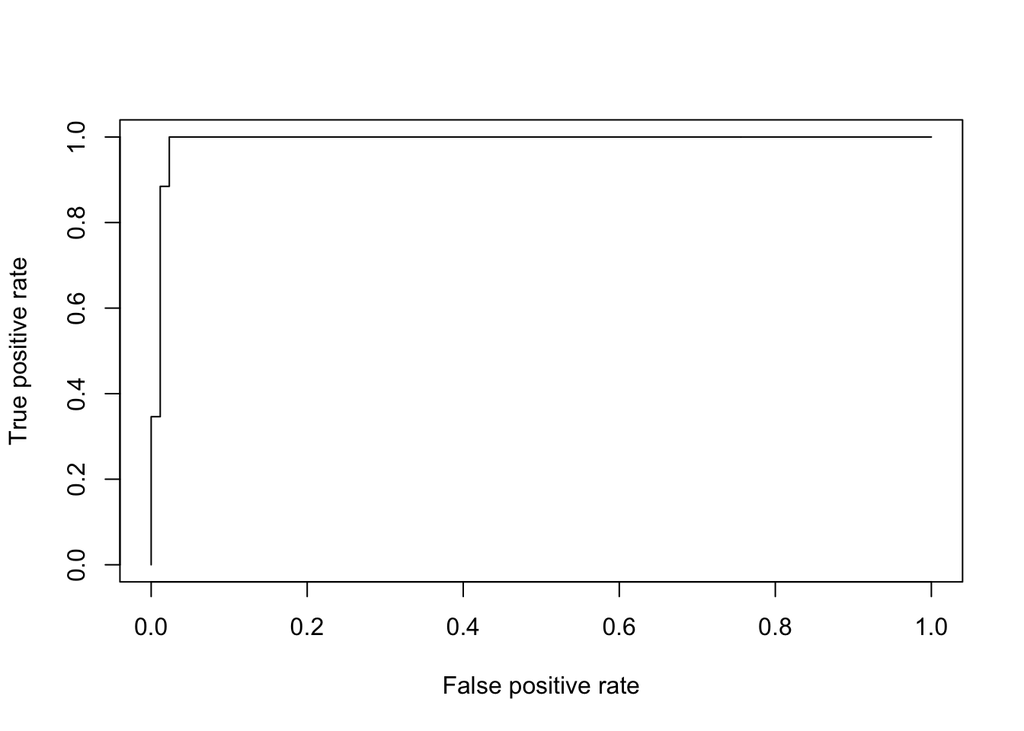

```r
# Compute AUC for predicting Class with the model
prob <- predict(glm.fit, newdata=test, type="response")
pred <- prediction(prob, test$Class)
perf <- performance(pred, measure = "tpr", x.measure = "fpr")
plot(perf)
```

```r
auc <- performance(pred, measure = "auc")
auc <- auc@y.values[[1]]
auc
```

```
## [1] 0.9910555
```

#### K-Nearest Neighbors

```r
library(class)
# Predict the labels of the test set simultaneously with the training of the model
prediction_knn <- knn(train[,2:10], test[,2:10], train$Class, k=4)
# Confusion matrix
table(prediction_knn, test$Class)
```

```
##
## prediction_knn benign malignant
##      benign        85         2
##      malignant      1        50
```

### Performance Estimation

Here we study performance estimation through sampling methods.

```r
# In case you do not have some of these packages installed, you should run the "install.packages()"command before the library() command the first time you want to run the code.
  library(RCurl)
  library(tidyverse)
  #install.packages("rafalib")
  library(rafalib)
```

```r
# Download data
  URL_text_1 <- "https://raw.githubusercontent.com/kannan-kasthuri/kannan-kasthuri.github.io"
  URL_text_2 <- "/master/Datasets/HANES/NYC_HANES_DIAB.csv"
  URL <- paste(URL_text_1,URL_text_2, sep="")
  HANES <- read.csv(text=getURL(URL))
  HANES$GENDER <- factor(HANES$GENDER, labels=c("M","F"))
  HANES$AGEGROUP <- factor(HANES$AGEGROUP, labels=c("20-39","40-59","60+"))
  HANES$HSQ_1 <- factor(HANES$HSQ_1, labels=c("Excellent","Very Good","Good", "Fair", "Poor"))
  HANES$DX_DBTS <- factor(HANES$DX_DBTS, labels=c("DIAB","DIAB NO_DX","NO DIAB"))
  HANES <- na.omit(HANES)
  str(HANES)
```

```
## 'data.frame':    1112 obs. of  23 variables:
##  $ KEY              : Factor w/ 1527 levels "133370A","133370B",..: 28 43 44 53 55 70 84 90 100 107 ...
##  $ GENDER           : Factor w/ 2 levels "M","F": 1 1 1 1 1 1 1 1 1 1 ...
##  $ SPAGE            : int  29 28 27 24 30 26 31 32 34 32 ...
##  $ AGEGROUP         : Factor w/ 3 levels "20-39","40-59",..: 1 1 1 1 1 1 1 1 1 1 ...
##  $ HSQ_1            : Factor w/ 5 levels "Excellent","Very Good",..: 2 2 2 1 1 3 1 2 1 3 ...
##  $ UCREATININE      : int  105 53 314 105 163 150 46 36 177 156 ...
##  $ UALBUMIN         : num  0.707 1 8 4 3 2 2 0.707 4 3 ...
##  $ UACR             : num  0.00673 2 3 4 2 ...
##  $ MERCURYU         : num  0.37 0.106 0.487 2.205 0.979 ...
##  $ DX_DBTS          : Factor w/ 3 levels "DIAB","DIAB NO_DX",..: 3 3 3 3 3 3 3 3 3 3 ...
##  $ A1C              : num  5 5.2 4.8 5.1 4.3 5.2 4.8 5.2 4.8 5.2 ...
##  $ CADMIUM          : num  0.2412 0.1732 0.0644 0.0929 0.1202 ...
##  $ LEAD             : num  1.454 1.019 0.863 1.243 0.612 ...
##  $ MERCURYTOTALBLOOD: num  2.34 2.57 1.32 14.66 2.13 ...
##  $ HDL              : int  42 51 42 61 52 50 57 56 42 44 ...
##  $ CHOLESTEROLTOTAL : int  184 157 145 206 120 155 156 235 156 120 ...
##  $ GLUCOSESI        : num  4.61 4.77 5.16 5 5.11 ...
##  $ CREATININESI     : num  74.3 73 80 84.9 66 ...
##  $ CREATININE       : num  0.84 0.83 0.91 0.96 0.75 0.99 0.9 0.84 0.93 1.09 ...
##  $ TRIGLYCERIDE     : int  156 43 108 65 51 29 31 220 82 35 ...
##  $ GLUCOSE          : int  83 86 93 90 92 85 72 87 96 92 ...
##  $ COTININE         : num  31.5918 0.0635 0.035 0.0514 0.035 ...
##  $ LDLESTIMATE      : int  111 97 81 132 58 99 93 135 98 69 ...
##  - attr(*, "na.action")=Class 'omit'  Named int [1:415] 2 15 16 24 26 28 33 34 35 39 ...
##   .. ..- attr(*, "names")= chr [1:415] "2" "15" "16" "24" ...
```

#### Sampling Methods

The validation set approach

```r
set.seed(1) # for reproducibility
# Choose the training set as half of the data
train=sample(1112,556)

# Train linear regression only on the train set using the "subset" option
lm.fit = lm(CHOLESTEROLTOTAL~ LDLESTIMATE ,data=HANES,subset=train)

# Predict the MSE on the test set
# you need to run the following command before you run the following one for the first time
attach(HANES)

mean((CHOLESTEROLTOTAL-predict(lm.fit,HANES))[-train]^2)
```

```
## [1] 295.9421
```

```r
# What it we choose a different train set?
set.seed(2)
train=sample(1112,556)
lm.fit=lm(CHOLESTEROLTOTAL~ LDLESTIMATE ,data=HANES,subset=train)
#attach(HANES)
mean((CHOLESTEROLTOTAL-predict(lm.fit,HANES))[-train]^2)
```

```
## [1] 278.2441
```

It can be observed that with this method, the MSE on the test set is very variable and depends directly on the initial partition of the data in half.

#### Leave-One-Out Cross-Validation (LOOCV)

```r
library(boot)
#Fit a linear regression model using glm function this time
glm.fit=glm(CHOLESTEROLTOTAL~ LDLESTIMATE ,data=HANES)
# Notice that there is no need to use a train and a test set this time. Why?

# Perform LOOCV
cv.err=cv.glm(HANES,glm.fit) #might take some time
cv.err$delta # This parameter includes the MSE in this case for LOOCV
```

```
## [1] 290.2582 290.2577
```

The first number is the MSE for the LOOCV and the second is the adjusted value.

#### K-fold Cross-Validation

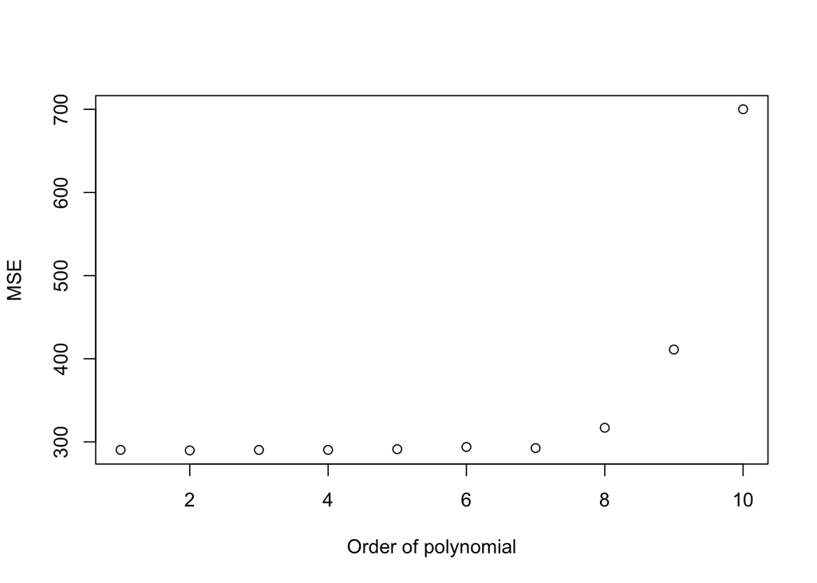

```r
# 10-fold CV
set.seed(17)
cv.error.10=rep(0,10) # create an empty vector to store the error values
for (i in 1:10){ # Try different order polynomials
  glm.fit=glm(CHOLESTEROLTOTAL~ poly(LDLESTIMATE,i) ,data=HANES)
  cv.error.10[i]=cv.glm(HANES,glm.fit,K=10)$delta[1] #extract the MSE error
}
#cv.error.10

plot(seq(1,10,1),cv.error.10, xlab = "Order of polynomial",ylab = "MSE")
```

### Regularization

We will now study regularization methods - Ridge regression and Lasso

```r
library(glmnet) # Library for regularization
# Make sure you have removed missing values from the data
# We have already done this at the beginning

# Select train and test sets
# Separate our data to train and test set - 90% train, 10% test
index <- sample(1:nrow(HANES),round(0.90*nrow(HANES)))
train <- HANES[index,]
test <- HANES[-index,]
```

#### Ridge Regression

```r
# Special syntax - matrix x and vector y
train$KEY <- NULL

x=model.matrix(CHOLESTEROLTOTAL~.,train)[,-1] # includes the predictors
y=train$CHOLESTEROLTOTAL # includes the variable we wish to predict

# Set lambda grid to explore all the models
grid=10^seq(10,-2,length=100)
ridge.mod<- glmnet(x, y, alpha=0, lambda = grid)
# alpha = 0 -> use L2 penalty -> regularization
# family = "binomial"

dim(coef(ridge.mod))
```

```
## [1]  27 100
```

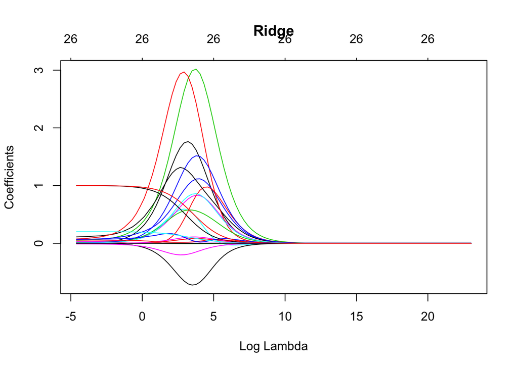

```r
# Plot coefficients
plot(ridge.mod, xvar="lambda",main='Ridge')
```

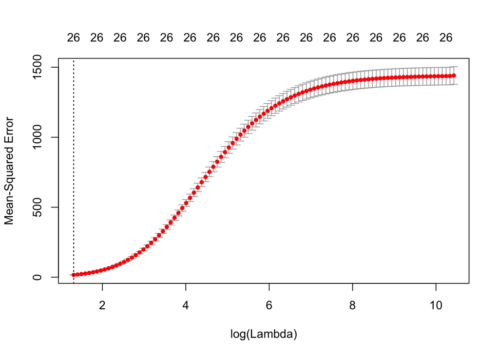

```r
set.seed(1)
# Perform cross validation to find the best value of lambda
cv.ridge <- cv.glmnet(x, y, alpha=0,nfolds=10)
plot(cv.ridge)
```

```r
bestlam=cv.ridge$lambda.min
bestlam
```

```
## [1] 3.710213
```

```r
# Predict MSE on the test set usind the best lambda
test$KEY <- NULL
x.test <- model.matrix(CHOLESTEROLTOTAL~.,test)[,-1] # includes the predictors
y.test <- test$CHOLESTEROLTOTAL

ridge.pred=predict(ridge.mod,s=bestlam,newx=x.test)
mean((ridge.pred-y.test)^2)
```

```
## [1] 12.33512
```

```r
# What if we used not to optimal lambda?
ridge.pred=predict(ridge.mod,s=15,newx=x.test)
mean((ridge.pred-y.test)^2)
```

```
## [1] 111.0305
```

#### Lasso

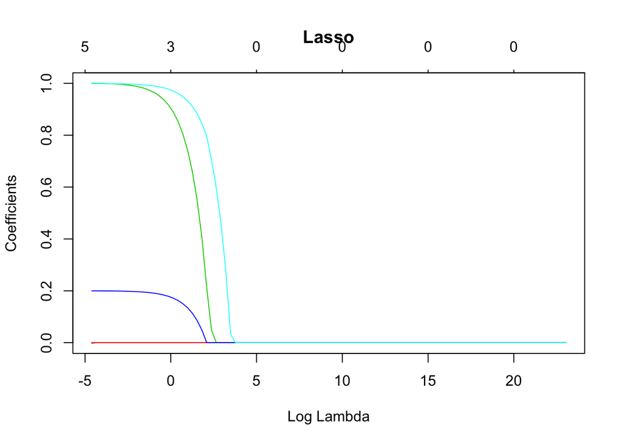

```r
lasso.mod<- glmnet(x, y, alpha=1, lambda = grid)
# Plot coefficients
plot(lasso.mod, xvar="lambda",main='Lasso')
```

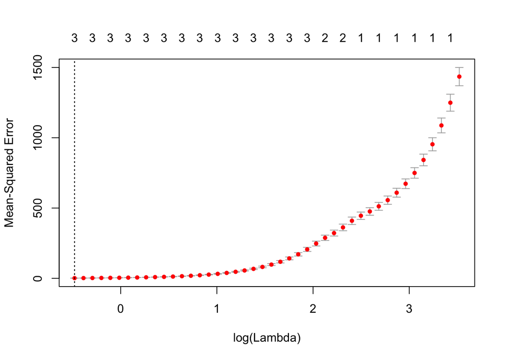

```r
set.seed(1)
# Perform cross validation to find the best value of lambda
cv.lasso <- cv.glmnet(x, y, alpha=1,nfolds=10)
plot(cv.lasso)
```

```r
bestlam=cv.lasso$lambda.min
bestlam
```

```
## [1] 0.6189008
```

```r
# Predict MSE on the test set usind the best lambda
lasso.pred=predict(lasso.mod,s=bestlam,newx=x.test)
mean((lasso.pred-y.test)^2)
```

```
## [1] 1.156176
```

```r
# What are the coefficients of the best model?
lasso.coef=predict(lasso.mod,type="coefficients",s=bestlam)[1:20,]
lasso.coef
```

```
##       (Intercept)           GENDERF             SPAGE     AGEGROUP40-59
##         6.5668852         0.0000000         0.0000000         0.0000000
##       AGEGROUP60+    HSQ_1Very Good         HSQ_1Good         HSQ_1Fair
##         0.0000000         0.0000000         0.0000000         0.0000000
##         HSQ_1Poor       UCREATININE          UALBUMIN              UACR
##         0.0000000         0.0000000         0.0000000         0.0000000
##          MERCURYU DX_DBTSDIAB NO_DX    DX_DBTSNO DIAB               A1C
##         0.0000000         0.0000000         0.0000000         0.0000000
##           CADMIUM              LEAD MERCURYTOTALBLOOD               HDL
##         0.0000000         0.0000000         0.0000000         0.9413246
```

```r
lasso.coef[lasso.coef!=0]
```

```
## (Intercept)         HDL
##   6.5668852   0.9413246
```